# HiFi Full-length 16S Analysis Report

## Summary QC statistics

- Samples number: 18
- Final samples number post-DADA2: 18
- Missing samples (Not enough reads, do not pass QC, etc):
- Total number of CCS reads before filtering and primers trimming: 393198
- Was primers trimmed prior to DADA2? Yes
- Note that if downsampling was enabled, the reads will be filtered first, then restricted to a maximum of N reads.
- Total number of reads after quality filtering: 393198 (100%)
- Total number of reads after primers trimming (DADA2 input): 382408 (97.26%)
- Total number of ASVs found: 1471
- Average number of ASVs per sample: 255
- Total number of reads in 1471 ASVs: 348474 (91.13% of all input reads)

### Classification using VSEARCH with a single database

- ASVs classified at Species level: 1350 (91.77%)
- ASVs classified at Species level (Excluding metagenome/uncultured entries): 1350 (91.77%)
- Percentage reads belong to ASV classified at Species level (Excluding metagenome/uncultured entries): 95%
- ASVs classified at Genus level: 1366 (92.86%)
- ASVs classified at Genus level (Excluding metagenome/uncultured entries): 1366 (92.86%)
- Percentage reads belong to ASV classified at Genus level (Excluding metagenome/uncultured entries): 98%

### Classification using Naive Bayes classifier with SILVA, GTDB and RefSeq + RDP

- ASVs classified at Species level: 1290 (87.7%)
- ASVs classified at Species level (Excluding metagenome/uncultured entries): 1290 (87.7%)
- Percentage reads belong to ASV classified at Species level (Excluding metagenome/uncultured entries): 90%
- ASVs classified at Genus level: 1360 (92.45%)
- ASVs classified at Genus level (Excluding metagenome/uncultured entries): 1341 (91.16%)
- Percentage reads belong to ASV classified at Genus level (Excluding metagenome/uncultured entries): 94%

## Overall reads filtering and number of full-length reads

- Full-length reads are defined as reads with both F27 and R1492 primers
- Note that full length counts column will only show if cutadapt was used to trim primers (default).

|  | Sample | Reads before quality filter | Reads after quality filter | Full-length Reads | Full-length Reads Percent |
| --- | --- | --- | --- | --- | --- |
| 1 | R11_1_P2C2 | 16195 | 16195 | 15552 | 0.960296387774004 |
| 2 | R11_1_P3C3 | 19627 | 19627 | 19312 | 0.983950680185459 |
| 3 | R3_1_P2C2 | 24657 | 24657 | 23560 | 0.955509591596707 |
| 4 | R3_1_P3C3 | 30983 | 30983 | 30393 | 0.980957299164058 |
| 5 | R3_2_P2C2 | 22799 | 22799 | 22000 | 0.964954603272073 |
| 6 | R3_2_P3C3 | 27505 | 27505 | 27068 | 0.984111979640065 |
| 7 | R3_3_P2C2 | 14675 | 14675 | 14134 | 0.963134582623509 |
| 8 | R3_3_P3C3 | 18783 | 18783 | 18488 | 0.984294308683384 |
| 9 | R9_1_P2C2 | 25306 | 25306 | 24092 | 0.952027187228325 |
| 10 | R9_1_P3C3 | 32133 | 32133 | 31488 | 0.979927177667818 |

[output cut: 8 more lines]

## Input reads QC (Before filtering and primers removal)

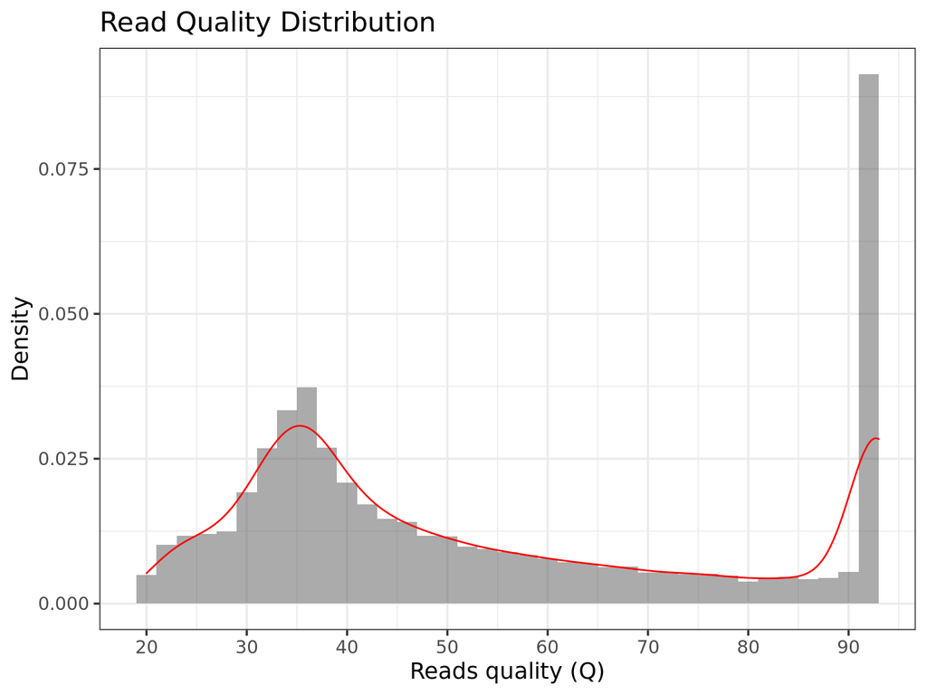

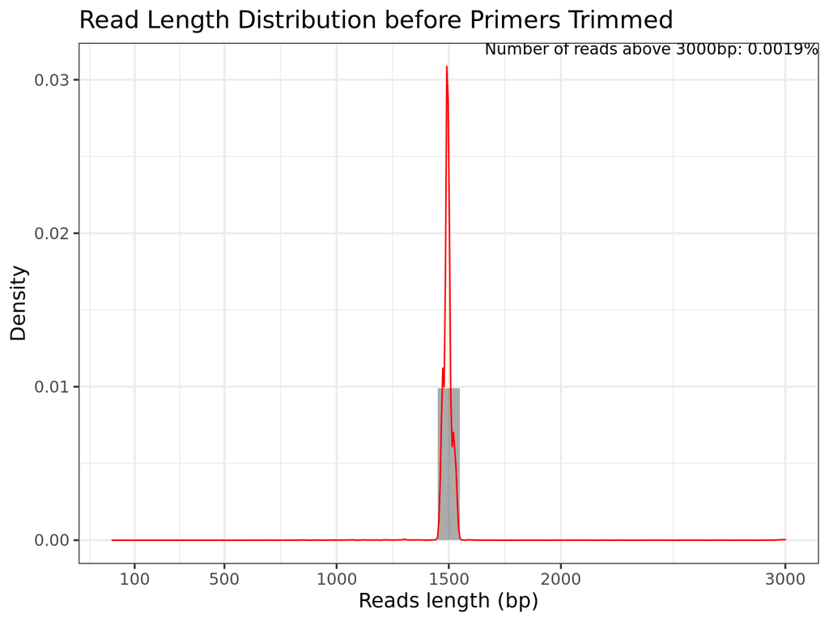

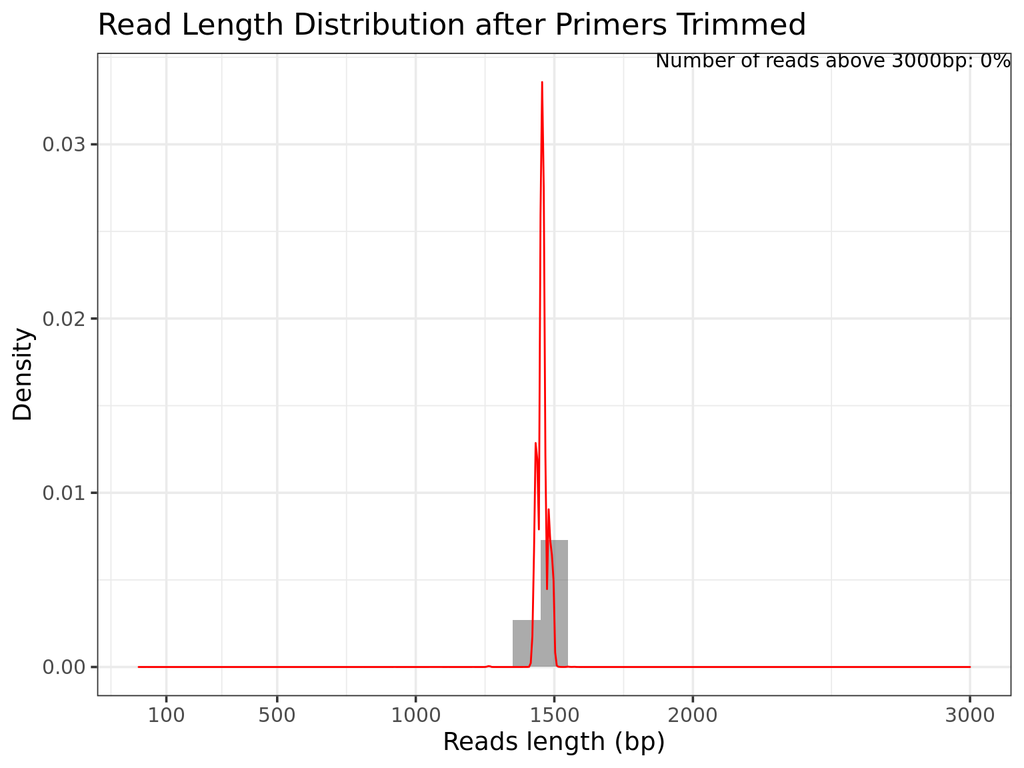

|  | Sample | Median Length (bp) | Median Read Quality | Length 1st Quartile (bp) | Length 3rd Quartile (bp) | Read Quality 1st Quartile (bp) | Read Quality 3rd Quartile (bp) |
| --- | --- | --- | --- | --- | --- | --- | --- |
| 1 | R11_1_P2C2 | 1493 | 36.74 | 1491 | 1495 | 30.3 | 49.04 |
| 2 | R11_1_P3C3 | 1493 | 67.1 | 1492 | 1495 | 41.29 | 93 |
| 3 | R3_1_P2C2 | 1475 | 36.59 | 1472 | 1502 | 30.54 | 47.12 |
| 4 | R3_1_P3C3 | 1473 | 62.7 | 1473 | 1503 | 40.61 | 92.97 |
| 5 | R3_2_P2C2 | 1516 | 36.85 | 1496 | 1521 | 30.59 | 49.8 |
| 6 | R3_2_P3C3 | 1517 | 67.8 | 1496 | 1519 | 41.73 | 93 |
| 7 | R3_3_P2C2 | 1502 | 37.26 | 1496 | 1507 | 30.66 | 50.42 |
| 8 | R3_3_P3C3 | 1503 | 71.78 | 1496 | 1504 | 42.72 | 93 |
| 9 | R9_1B_P2C2 | 1489 | 36.85 | 1478 | 1501 | 30.44 | 49.06 |
| 10 | R9_1B_P3C3 | 1489 | 68.71 | 1477 | 1501 | 41.68 | 93 |

[output cut: 8 more lines]

## DADA2 QC metrics

|  | sample-id | input | filtered | percentage of input passed filter | denoised | non-chimeric | percentage of input non-chimeric | n_ASV |
| --- | --- | --- | --- | --- | --- | --- | --- | --- |
| 1 | R11_1_P2C2 | 15552 | 12661 | 81.41 | 12551 | 12533 | 80.59 | 177 |
| 2 | R11_1_P3C3 | 19312 | 19312 | 100 | 19136 | 19106 | 98.93 | 195 |
| 3 | R3_1_P2C2 | 23560 | 19428 | 82.46 | 19349 | 19349 | 82.13 | 94 |
| 4 | R3_1_P3C3 | 30393 | 30393 | 100 | 30292 | 30292 | 99.67 | 107 |
| 5 | R3_2_P2C2 | 22000 | 18076 | 82.16 | 17911 | 17891 | 81.32 | 149 |
| 6 | R3_2_P3C3 | 27068 | 27067 | 100 | 26821 | 26799 | 99.01 | 176 |
| 7 | R3_3_P2C2 | 14134 | 11596 | 82.04 | 11565 | 11517 | 81.48 | 85 |
| 8 | R3_3_P3C3 | 18488 | 18488 | 100 | 18449 | 18371 | 99.37 | 92 |
| 9 | R9_1_P2C2 | 24092 | 19828 | 82.3 | 19644 | 19644 | 81.54 | 131 |
| 10 | R9_1_P3C3 | 31488 | 31485 | 99.99 | 31228 | 31157 | 98.95 | 172 |

[output cut: 8 more lines]

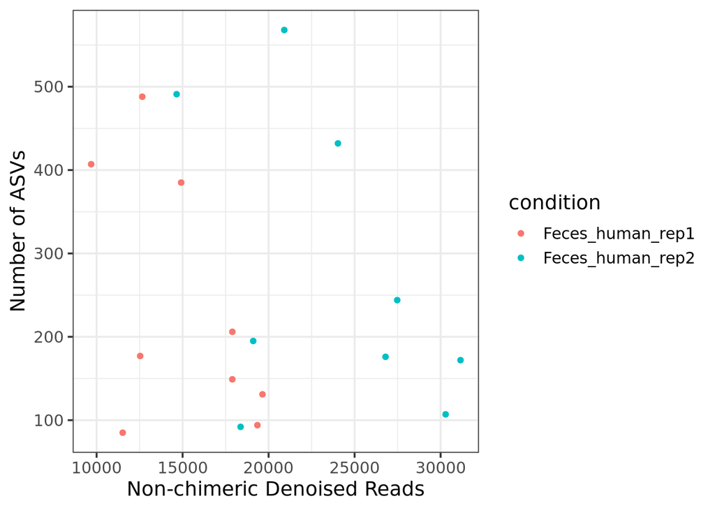

## Top Taxa and Plots

- For interactive view, use the Emperor QZV output from QIIME2 in `results/core-metrics-diversity` folder with QIIME2 View
- Note that if the distances between all samples are zero for a specific method, the plots will not be shown.
- MDS plots use ASVs as input.
- Samples might be missing due to choice of rarefecation depth. Rerun pipeline with `-resume --rarefaction_depth X` to choose a custom rarefaction depth X.

### Bray-Curtis MDS plot

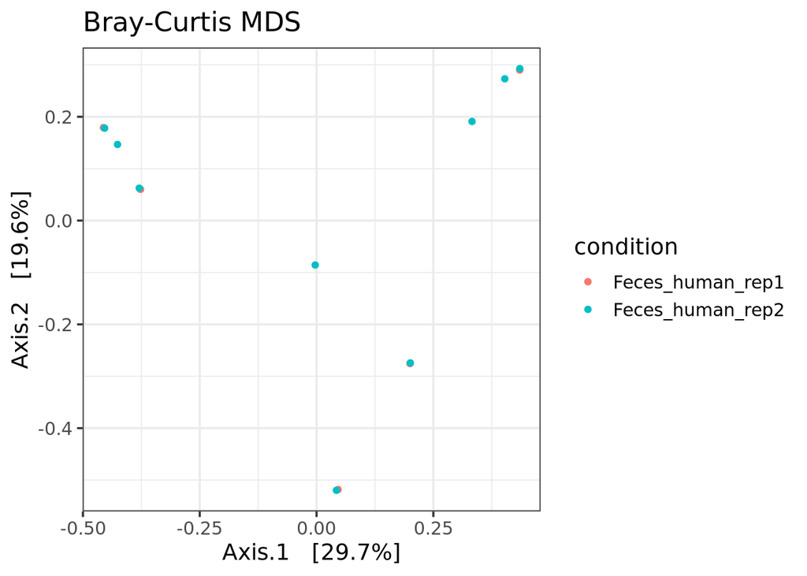

### Weighted and Unweighted Unifrac MDS plot

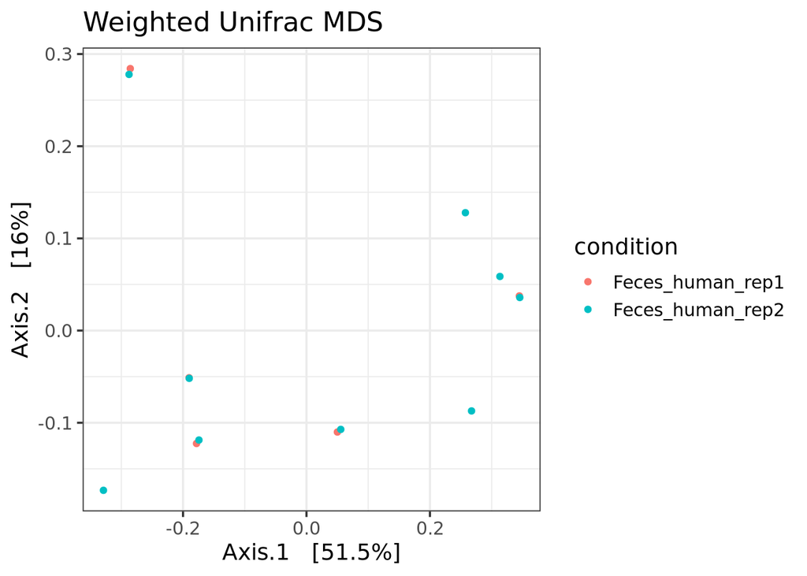

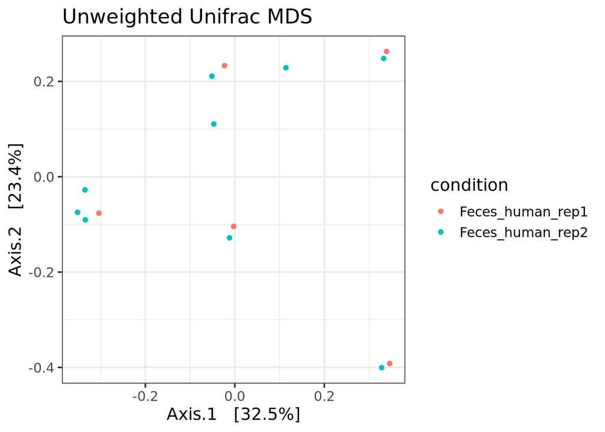

### Top 50 ASVs (VSEARCH classification)

|  | OTU | Kingdom | Phylum | Class | Order | Family | Genus | Species | R3_3_P3C3 | R9_1B_P3C3 | R3_2_P2C2 | R9_4_P3C3 | R11_1_P2C2 | R9_1_P2C2 | R9_4_P2C2 | R3_2_P3C3 | R3_3_P2C2 | R9_1_P3C3 | R3_1_P2C2 | R9_1B_P2C2 | R9_3_P2C2 | R9_2_P2C2 | R11_1_P3C3 | R3_1_P3C3 | R9_3_P3C3 | R9_2_P3C3 |
| --- | --- | --- | --- | --- | --- | --- | --- | --- | --- | --- | --- | --- | --- | --- | --- | --- | --- | --- | --- | --- | --- | --- | --- | --- | --- | --- |
| 1 | b3cf52ed010a86d6b156abeec5546ac2 | Bacteria | Verrucomicrobiota | Verrucomicrobiae | Verrucomicrobiales | Akkermansiaceae | Akkermansia | Akkermansia muciniphila | 0 | 0 | 0 | 0 | 0 | 0 | 0 | 0 | 0 | 0 | 10685 | 0 | 0 | 0 | 0 | 16616 | 0 | 0 |
| 2 | 7cd303c061a8e92e5605444f23d878ad | Bacteria | Firmicutes C | Negativicutes | Acidaminococcales | Acidaminococcaceae | Acidaminococcus | Acidaminococcus intestini | 974 | 0 | 5033 | 0 | 23 | 0 | 0 | 7669 | 596 | 0 | 0 | 0 | 0 | 0 | 36 | 0 | 0 | 0 |
| 3 | e602f10e09e703ff710431cd5334d6eb | Bacteria | Proteobacteria | Gammaproteobacteria | Enterobacterales | Enterobacteriaceae | Escherichia | Escherichia coli | 3438 | 0 | 575 | 0 | 0 | 0 | 0 | 853 | 2097 | 0 | 990 | 0 | 0 | 0 | 0 | 1573 | 0 | 0 |
| 4 | e07a5958b141ef24e8bd71c945149d30 | Bacteria | Bacteroidota | Bacteroidia | Bacteroidales | Bacteroidaceae | Alloprevotella |  | 1962 | 3 | 2165 | 3 | 0 | 16 | 1 | 3290 | 1232 | 29 | 48 | 0 | 0 | 1 | 0 | 71 | 1 | 0 |
| 5 | 1947cfed2cb134c8d255df38fb75dab7 | Bacteria | Firmicutes | Bacilli | Erysipelotrichales | Erysipelotrichaceae | Holdemanella | Holdemanella porci | 0 | 0 | 0 | 686 | 0 | 0 | 455 | 0 | 0 | 0 | 0 | 0 | 309 | 1962 | 0 | 0 | 464 | 3209 |
| 6 | 28a84f7ece5bc05b69d26f7152fe7f7d | Bacteria | Firmicutes A | Clostridia | Oscillospirales | Acutalibacteraceae | Ruminococcus E | Ruminococcus E bromii B | 0 | 0 | 0 | 403 | 0 | 0 | 255 | 0 | 1 | 0 | 0 | 0 | 669 | 1753 | 0 | 0 | 1148 | 2839 |
| 7 | 7fd66609c3c3e21a8ba382af98af80d1 | Bacteria | Proteobacteria | Gammaproteobacteria | Enterobacterales | Enterobacteriaceae | Klebsiella | Klebsiella pneumoniae | 0 | 79 | 0 | 0 | 0 | 2157 | 0 | 0 | 0 | 3251 | 0 | 53 | 0 | 0 | 0 | 0 | 0 | 0 |
| 8 | 52295bc5c46e0f9883a6c87a1fa228e5 | Bacteria | Proteobacteria | Gammaproteobacteria | Enterobacterales | Enterobacteriaceae | Klebsiella | Klebsiella pneumoniae | 0 | 51 | 0 | 0 | 0 | 2130 | 0 | 0 | 0 | 3101 | 0 | 51 | 0 | 0 | 0 | 0 | 0 | 0 |
| 9 | eed52901e2d1fc2b7301e43413375d56 | Bacteria | Firmicutes A | Clostridia | Lachnospirales | CAG-274 | CAG-274 | CAG-274 sp900545305 | 0 | 3183 | 2 | 0 | 0 | 0 | 0 | 0 | 0 | 0 | 0 | 2113 | 0 | 0 | 0 | 0 | 0 | 0 |
| 10 | 0277dd98a8c623d2ca4a1bf1d1452247 | Bacteria | Firmicutes C | Negativicutes | Veillonellales | Megasphaeraceae | Megasphaera | Megasphaera massiliensis | 250 | 0 | 987 | 0 | 0 | 0 | 0 | 1502 | 143 | 0 | 429 | 0 | 0 | 0 | 0 | 722 | 0 | 0 |

[output cut: 40 more lines]

### Top 10 Classified Genus (Collapsed to species) with VSEARCH

- Relative abundance is calculated by dividing the number of reads for each ASV to the total number of reads in each sample.
- Heatmap contains only species with >1% abundance in at least 2 samples for the top 10 genus.

|  | Genus | Mean supporting reads across samples | Mean relative abundance across samples |
| --- | --- | --- | --- |
| 1 | Escherichia | 1797.72 | 0.09 |
| 2 | Akkermansia | 1542 | 0.06 |
| 3 | Blautia A | 976.28 | 0.06 |
| 4 | Klebsiella | 1584.61 | 0.06 |
| 5 | Acidaminococcus | 879.17 | 0.04 |
| 6 | Megasphaera | 771.44 | 0.04 |
| 7 | Alloprevotella | 614.56 | 0.03 |
| 8 | Bacteroides | 426.17 | 0.03 |
| 9 | Gemmiger | 522.5 | 0.03 |
| 10 | Holdemanella | 439.61 | 0.03 |

|  | Genus | Species | R3_3_P3C3 | R9_1B_P3C3 | R3_2_P2C2 | R9_4_P3C3 | R11_1_P2C2 | R9_1_P2C2 | R9_4_P2C2 | R3_2_P3C3 | R3_3_P2C2 | R9_1_P3C3 | R3_1_P2C2 | R9_1B_P2C2 | R9_3_P2C2 | R9_2_P2C2 | R11_1_P3C3 | R3_1_P3C3 | R9_3_P3C3 | R9_2_P3C3 |
| --- | --- | --- | --- | --- | --- | --- | --- | --- | --- | --- | --- | --- | --- | --- | --- | --- | --- | --- | --- | --- |
| 1 | Escherichia | Escherichia coli | 7889 | 5453 | 1390 | 0 | 0 | 350 | 0 | 1962 | 4944 | 534 | 2338 | 3668 | 52 | 5 | 0 | 3708 | 58 | 8 |
| 2 | Akkermansia | Akkermansia muciniphila | 0 | 0 | 1 | 0 | 0 | 0 | 0 | 0 | 0 | 0 | 10687 | 0 | 0 | 0 | 0 | 16625 | 0 | 0 |
| 3 | Akkermansia | Akkermansia sp004167605 | 0 | 0 | 0 | 216 | 0 | 0 | 186 | 0 | 0 | 0 | 0 | 0 | 15 | 0 | 0 | 0 | 26 | 0 |
| 4 | Blautia A | Blautia A caecimuris | 3 | 0 | 70 | 1 | 1281 | 0 | 4 | 118 | 2 | 0 | 0 | 0 | 0 | 0 | 1964 | 0 | 0 | 0 |
| 5 | Blautia A | Blautia A faecis | 0 | 0 | 0 | 65 | 0 | 0 | 55 | 8 | 0 | 0 | 0 | 0 | 530 | 229 | 0 | 0 | 806 | 308 |
| 6 | Blautia A | Blautia A hydrogenotrophica | 0 | 0 | 19 | 0 | 0 | 0 | 0 | 29 | 0 | 0 | 0 | 0 | 0 | 0 | 0 | 0 | 0 | 0 |
| 7 | Blautia A | Blautia A luti | 0 | 0 | 0 | 5 | 0 | 0 | 0 | 0 | 0 | 0 | 0 | 0 | 0 | 0 | 0 | 0 | 0 | 0 |
| 8 | Blautia A | Blautia A massiliensis | 5 | 0 | 105 | 111 | 0 | 0 | 80 | 145 | 0 | 0 | 0 | 0 | 438 | 517 | 0 | 0 | 702 | 873 |
| 9 | Blautia A | Blautia A obeum | 0 | 0 | 0 | 429 | 0 | 0 | 349 | 0 | 0 | 0 | 0 | 0 | 565 | 564 | 0 | 0 | 914 | 933 |
| 10 | Blautia A | Blautia A obeum B | 0 | 0 | 0 | 27 | 0 | 0 | 7 | 8 | 0 | 0 | 0 | 0 | 6 | 15 | 0 | 0 | 12 | 20 |

[output cut: 30 more lines]

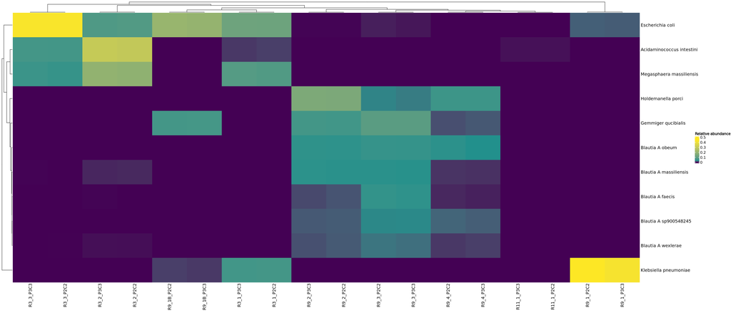

### Top 50 ASVs (Naive Bayes Classifier)

|  | OTU | Kingdom | Phylum | Class | Order | Family | Genus | Species | R3_3_P3C3 | R9_1B_P3C3 | R3_2_P2C2 | R9_4_P3C3 | R11_1_P2C2 | R9_1_P2C2 | R9_4_P2C2 | R3_2_P3C3 | R3_3_P2C2 | R9_1_P3C3 | R3_1_P2C2 | R9_1B_P2C2 | R9_3_P2C2 | R9_2_P2C2 | R11_1_P3C3 | R3_1_P3C3 | R9_3_P3C3 | R9_2_P3C3 |
| --- | --- | --- | --- | --- | --- | --- | --- | --- | --- | --- | --- | --- | --- | --- | --- | --- | --- | --- | --- | --- | --- | --- | --- | --- | --- | --- |
| 1 | b3cf52ed010a86d6b156abeec5546ac2 | Bacteria | Verrucomicrobiota | Verrucomicrobiae | Verrucomicrobiales | Akkermansiaceae | Akkermansia | Akkermansia muciniphila | 0 | 0 | 0 | 0 | 0 | 0 | 0 | 0 | 0 | 0 | 10685 | 0 | 0 | 0 | 0 | 16616 | 0 | 0 |
| 2 | 7cd303c061a8e92e5605444f23d878ad | Bacteria | Firmicutes | Negativicutes | Acidaminococcales | Acidaminococcaceae | Acidaminococcus | Acidaminococcus intestini | 974 | 0 | 5033 | 0 | 23 | 0 | 0 | 7669 | 596 | 0 | 0 | 0 | 0 | 0 | 36 | 0 | 0 | 0 |
| 3 | e602f10e09e703ff710431cd5334d6eb | Bacteria | Proteobacteria | Gammaproteobacteria | Enterobacterales | Enterobacteriaceae | Escherichia-Shigella | Escherichia-Shigella coli | 3438 | 0 | 575 | 0 | 0 | 0 | 0 | 853 | 2097 | 0 | 990 | 0 | 0 | 0 | 0 | 1573 | 0 | 0 |
| 4 | e07a5958b141ef24e8bd71c945149d30 | Bacteria | Proteobacteria | Gammaproteobacteria | Burkholderiales | Burkholderiaceae | Sutterella | Sutterella wadsworthensis A | 1962 | 3 | 2165 | 3 | 0 | 16 | 1 | 3290 | 1232 | 29 | 48 | 0 | 0 | 1 | 0 | 71 | 1 | 0 |
| 5 | 1947cfed2cb134c8d255df38fb75dab7 | Bacteria | Firmicutes | Bacilli | Erysipelotrichales | Erysipelotrichaceae | Faecalicoccus | Faecalicoccus acidiformans | 0 | 0 | 0 | 686 | 0 | 0 | 455 | 0 | 0 | 0 | 0 | 0 | 309 | 1962 | 0 | 0 | 464 | 3209 |
| 6 | 28a84f7ece5bc05b69d26f7152fe7f7d | Bacteria | Firmicutes A | Clostridia | Oscillospirales | Acutalibacteraceae | Ruminococcus E | Ruminococcus E bromii A | 0 | 0 | 0 | 403 | 0 | 0 | 255 | 0 | 1 | 0 | 0 | 0 | 669 | 1753 | 0 | 0 | 1148 | 2839 |
| 7 | 7fd66609c3c3e21a8ba382af98af80d1 | Bacteria | Proteobacteria | Gammaproteobacteria | Enterobacterales | Enterobacteriaceae | Klebsiella | Klebsiella pneumoniae | 0 | 79 | 0 | 0 | 0 | 2157 | 0 | 0 | 0 | 3251 | 0 | 53 | 0 | 0 | 0 | 0 | 0 | 0 |
| 8 | 52295bc5c46e0f9883a6c87a1fa228e5 | Bacteria | Proteobacteria | Gammaproteobacteria | Enterobacterales | Enterobacteriaceae | Klebsiella | Klebsiella pneumoniae | 0 | 51 | 0 | 0 | 0 | 2130 | 0 | 0 | 0 | 3101 | 0 | 51 | 0 | 0 | 0 | 0 | 0 | 0 |
| 9 | eed52901e2d1fc2b7301e43413375d56 | Bacteria | Firmicutes | Clostridia | Clostridiales | Lachnospiraceae | Tyzzerella | Tyzzerella colinum | 0 | 3183 | 2 | 0 | 0 | 0 | 0 | 0 | 0 | 0 | 0 | 2113 | 0 | 0 | 0 | 0 | 0 | 0 |
| 10 | 0277dd98a8c623d2ca4a1bf1d1452247 | Bacteria | Firmicutes | Negativicutes | Veillonellales | Veillonellaceae | Megasphaera | Megasphaera massiliensis | 250 | 0 | 987 | 0 | 0 | 0 | 0 | 1502 | 143 | 0 | 429 | 0 | 0 | 0 | 0 | 722 | 0 | 0 |

[output cut: 40 more lines]

### Top 10 Classified Genus (Collapsed to species) with Naive Bayes Classifier

- Relative abundance is calculated by dividing the number of reads for each ASV to the total number of reads in each sample.
- Heatmap contains only species with >1% abundance in at least 2 samples for the top 10 genus.

|  | Genus | Mean supporting reads across samples | Mean relative abundance across samples |
| --- | --- | --- | --- |
| 1 | Akkermansia | 1541.33 | 0.06 |
| 2 | Escherichia-Shigella | 1061.56 | 0.06 |
| 3 | Klebsiella | 1583.94 | 0.06 |
| 4 | Sutterella | 876.39 | 0.05 |
| 5 | Acidaminococcus | 879.17 | 0.04 |
| 6 | Blautia | 673 | 0.04 |
| 7 | Blautia A | 620.11 | 0.04 |
| 8 | Megasphaera | 771.44 | 0.04 |
| 9 | Bacteroides | 405.94 | 0.03 |
| 10 | Dorea | 440.44 | 0.03 |

[output cut: 2 more lines]

|  | Genus | Species | R3_3_P3C3 | R9_1B_P3C3 | R3_2_P2C2 | R9_4_P3C3 | R11_1_P2C2 | R9_1_P2C2 | R9_4_P2C2 | R3_2_P3C3 | R3_3_P2C2 | R9_1_P3C3 | R3_1_P2C2 | R9_1B_P2C2 | R9_3_P2C2 | R9_2_P2C2 | R11_1_P3C3 | R3_1_P3C3 | R9_3_P3C3 | R9_2_P3C3 |
| --- | --- | --- | --- | --- | --- | --- | --- | --- | --- | --- | --- | --- | --- | --- | --- | --- | --- | --- | --- | --- |
| 1 | Akkermansia | Akkermansia muciniphila | 0 | 0 | 0 | 0 | 0 | 0 | 0 | 0 | 0 | 0 | 10685 | 0 | 0 | 0 | 0 | 16616 | 0 | 0 |
| 2 | Akkermansia | Akkermansia sp004167605 | 0 | 0 | 0 | 216 | 0 | 0 | 186 | 0 | 0 | 0 | 0 | 0 | 15 | 0 | 0 | 0 | 26 | 0 |
| 3 | Escherichia-Shigella | Escherichia-Shigella boydii | 0 | 782 | 0 | 0 | 0 | 8 | 0 | 0 | 0 | 13 | 0 | 532 | 0 | 0 | 0 | 0 | 0 | 0 |
| 4 | Escherichia-Shigella | Escherichia-Shigella coli | 5627 | 806 | 965 | 0 | 0 | 257 | 0 | 1387 | 3468 | 403 | 1640 | 556 | 0 | 2 | 0 | 2644 | 16 | 2 |
| 5 | Klebsiella | Klebsiella grimontii | 0 | 0 | 0 | 0 | 0 | 94 | 0 | 0 | 0 | 114 | 24 | 0 | 0 | 0 | 0 | 16 | 0 | 0 |
| 6 | Klebsiella | Klebsiella michiganensis | 0 | 1 | 0 | 0 | 0 | 822 | 0 | 0 | 0 | 1401 | 0 | 0 | 0 | 0 | 0 | 9 | 0 | 0 |
| 7 | Klebsiella | Klebsiella oxytoca | 0 | 0 | 0 | 0 | 0 | 156 | 0 | 0 | 0 | 241 | 0 | 0 | 0 | 0 | 0 | 0 | 0 | 0 |
| 8 | Klebsiella | Klebsiella pneumoniae | 0 | 253 | 0 | 0 | 0 | 8621 | 0 | 0 | 0 | 13133 | 1170 | 191 | 0 | 0 | 0 | 1747 | 0 | 0 |
| 9 | Klebsiella | Klebsiella sp003752615 | 0 | 0 | 0 | 0 | 0 | 0 | 0 | 0 | 0 | 0 | 0 | 0 | 21 | 0 | 0 | 0 | 25 | 0 |
| 10 | Klebsiella | Unclassified | 0 | 0 | 0 | 0 | 0 | 0 | 0 | 0 | 0 | 0 | 205 | 0 | 0 | 0 | 0 | 267 | 0 | 0 |

[output cut: 38 more lines]

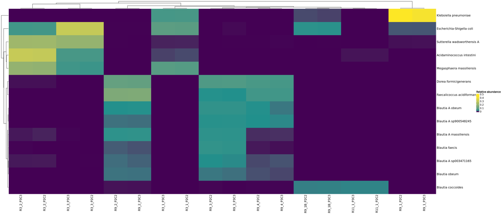